# Venlafaxine - 18S beta diversity analysis

Milena Esser

2025-05-20

## 1 Biofilm

### 1.1 PCoA Bray Curtis

Performed Principal Coordinates Analysis (PCoA) on the phyloseq object using Bray-Curtis distance. This method reduces multidimensional microbial community data into principal axes to visualize sample similarities.

*PCoA plot*

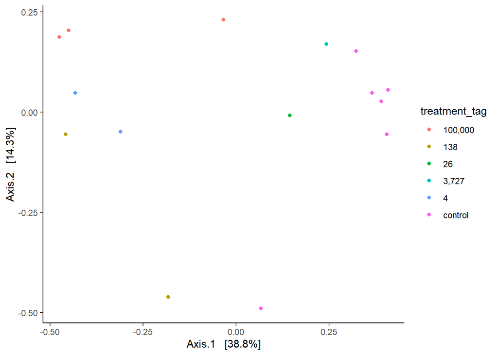

### 1.2 NMDS Bray Curtis

I looked at 2D (k=2) and 3D (k=3) NMDS

Interpretation of stress values:

- < 0.05 = excellent,
- 0.05–0.1 = very good,
- 0.1–0.2 = usable but some distortion,
- > 0.2 = not reliable

Weak ties mean that few identical distances were tied during ranking, which is good, it indicates the data have good variability.

```
## Square root transformation
## Wisconsin double standardization
## *** Best solution repeated 8 times
```

```
## NMDS with k=3 results:
```

```
## Stress value: 0.0779211
```

```
## Square root transformation
## Wisconsin double standardization
## *** Best solution repeated 2 times
```

```
## NMDS with k=2 results:
```

```
## Stress value: 0.1376673
```

Based on stress values, I continued with:

```
## Selected model: ord_NMDS_k2 ; Stress value: 0.1376673
```

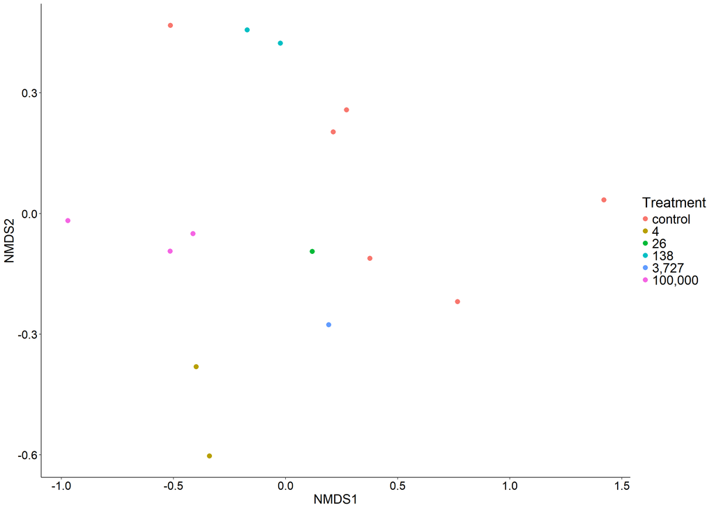

#### 1.2.1 Statistics

##### 1.2.1.1 PERMANOVA

```
## PERMANOVA Results for Bray-Curtis Distance:
```

```
## Testing effects of treatment on microbial community composition.
```

```
##          Df SumOfSqs        R2        F Pr(>F)
## Model     5 2.803952 0.6175046 2.905939  0.001
## Residual  9 1.736827 0.3824954       NA     NA
## Total    14 4.540778 1.0000000       NA     NA
```

```
##
## Interpretation:
```

```
## - Significant p-values (< 0.05) indicate a statistically significant effect of that factor on community composition.
```

```
## - R² values represent the proportion of variation explained by each factor.
```

##### 1.2.1.2 Beta dispersion

betadisper measures the spread (i.e., variability) of samples around the group centroid in NMDS (or distance) space. It’s analogous to a Levene’s test for homogeneity of variance, but for multivariate data. It helps to understand if your PERMANOVA results are driven more by location (centroid differences) or spread (dispersion differences).

- **If p > 0.05**: No evidence of unequal dispersion → You can trust group separation in PERMANOVA.
- **If p < 0.05**: Significant dispersion → Group differences in PERMANOVA **may be confounded** by group variance, **not just location**.

```
## Analysis of Variance Table
##
## Response: Distances
##           Df  Sum Sq  Mean Sq F value Pr(>F)
## Groups     5 0.31642 0.063283  1.5718 0.2615
## Residuals  9 0.36236 0.040262
```

```
## Summary of distances to group centroids:
```

```
##       treatment DistanceToCentroid
## VenBB   100,000         0.66887601
## VenDD   100,000         0.00000000
## VenD    100,000         0.06941305
## VenF    control         0.43733851
## VenG    control         0.42889499
## VenH    control         0.42936586
```

Create boxplot

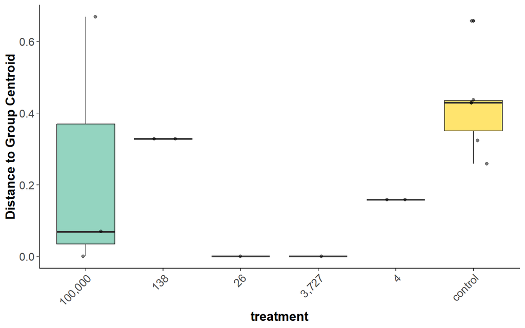

## 2 Sediment

### 2.1 PCoA Bray Curtis

Performed Principal Coordinates Analysis (PCoA) on the phyloseq object using Bray-Curtis distance. This method reduces multidimensional microbial community data into principal axes to visualize sample similarities.

*PCoA plot*

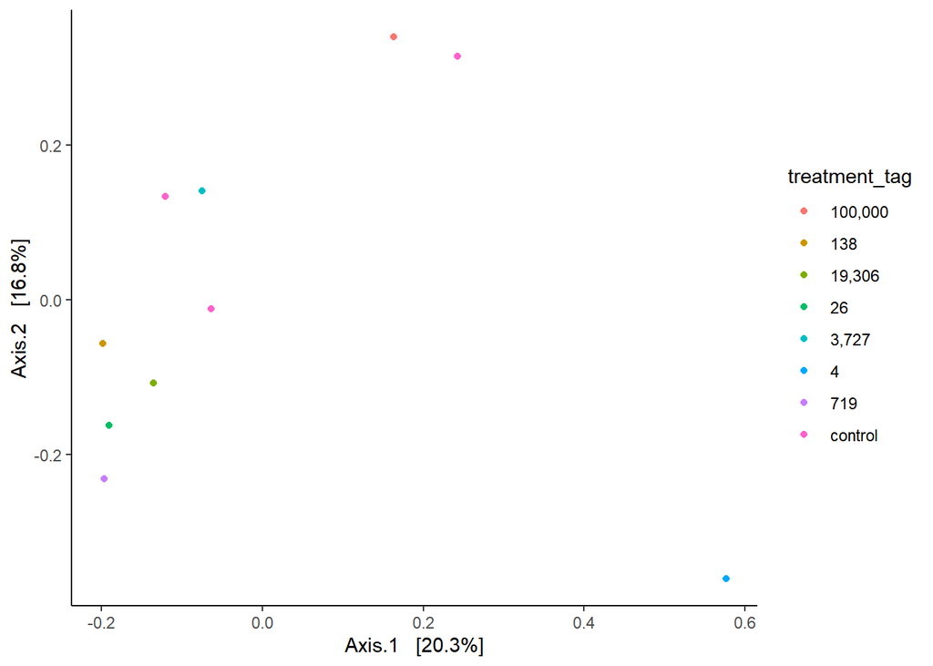

### 2.2 NMDS Bray Curtis

I looked at 2D (k=2) and 3D (k=3) NMDS

Interpretation of stress values:

- < 0.05 = excellent,
- 0.05–0.1 = very good,
- 0.1–0.2 = usable but some distortion,
- > 0.2 = not reliable

Weak ties mean that few identical distances were tied during ranking, which is good, it indicates the data have good variability.

```
## Square root transformation
## Wisconsin double standardization
## *** Best solution repeated 6 times
```

```
## NMDS with k=3 results:
```

```
## Stress value: 0.02836469
```

```
## Square root transformation
## Wisconsin double standardization
## *** Best solution repeated 6 times
```

```
## NMDS with k=2 results:
```

```
## Stress value: 0.08457711
```

Based on stress values, I continued with:

```
## Selected model: ord_NMDS_k2 ; Stress value: 0.08457711
```

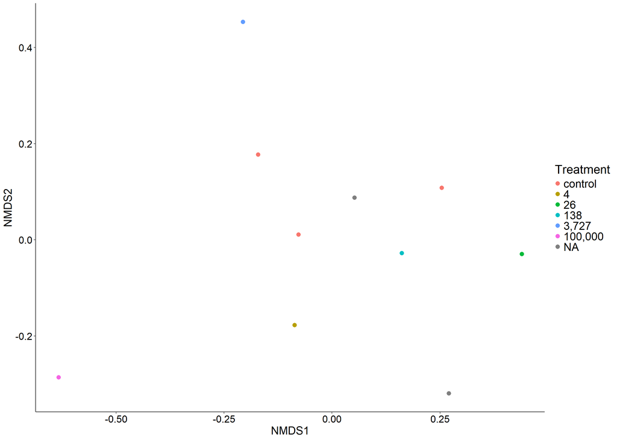

#### 2.2.1 Statistics

##### 2.2.1.1 PERMANOVA

```
## PERMANOVA Results for Bray-Curtis Distance:
```

```
## Testing effects of treatment on microbial community composition.
```

```
##          Df  SumOfSqs       R2         F Pr(>F)
## Model     7 2.1877496 0.771155 0.9627913  0.519
## Residual  2 0.6492283 0.228845        NA     NA
## Total     9 2.8369778 1.000000        NA     NA
```

```
##
## Interpretation:
```

```
## - Significant p-values (< 0.05) indicate a statistically significant effect of that factor on community composition.
```

```
## - R² values represent the proportion of variation explained by each factor.
```

##### 2.2.1.2 Beta dispersion

betadisper measures the spread (i.e., variability) of samples around the group centroid in NMDS (or distance) space. It’s analogous to a Levene’s test for homogeneity of variance, but for multivariate data. It helps to understand if your PERMANOVA results are driven more by location (centroid differences) or spread (dispersion differences).

- **If p > 0.05**: No evidence of unequal dispersion → You can trust group separation in PERMANOVA.
- **If p < 0.05**: Significant dispersion → Group differences in PERMANOVA **may be confounded** by group variance, **not just location**.

```
## Analysis of Variance Table
##
## Response: Distances
##           Df  Sum Sq  Mean Sq F value Pr(>F)
## Groups     7 0.45113 0.064447  13.556 0.0704 .
## Residuals  2 0.00951 0.004754
## ---
## Signif. codes:  0 '***' 0.001 '**' 0.01 '*' 0.05 '.' 0.1 ' ' 1
```

```
## Summary of distances to group centroids:
```

```
##     treatment DistanceToCentroid
## 10S         4          0.0000000
## 1S        719          0.0000000
## 2S        138          0.0000000
## 3S         26          0.0000000
## 4S    control          0.4771072
## 5S     19,306          0.0000000
```

Create boxplot

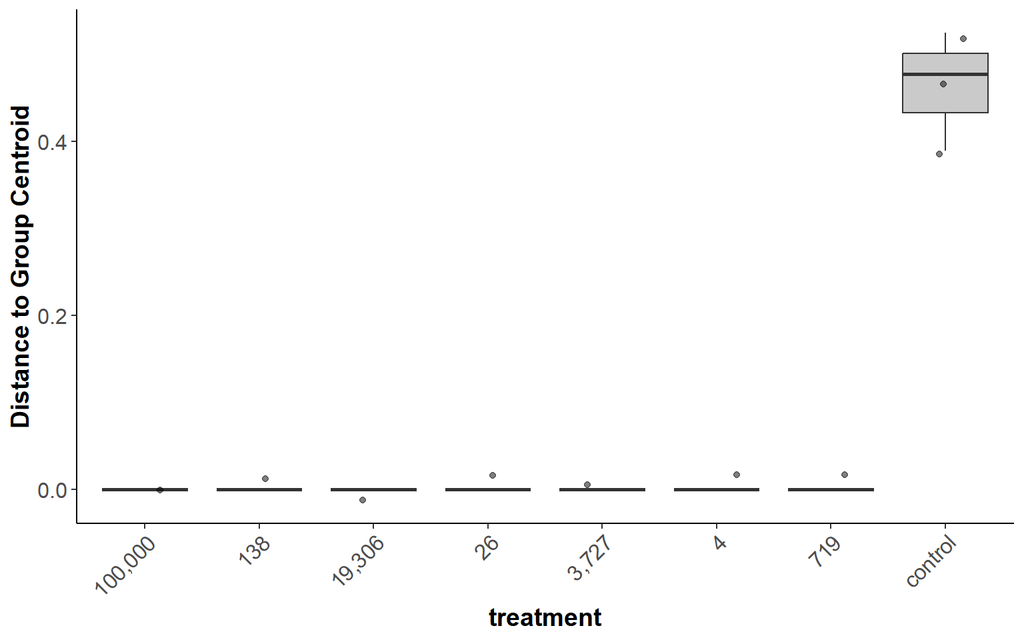

## 3 Water

### 3.1 PCoA Bray Curtis

Performed Principal Coordinates Analysis (PCoA) on the phyloseq object using Bray-Curtis distance. This method reduces multidimensional microbial community data into principal axes to visualize sample similarities.

*PCoA plot*

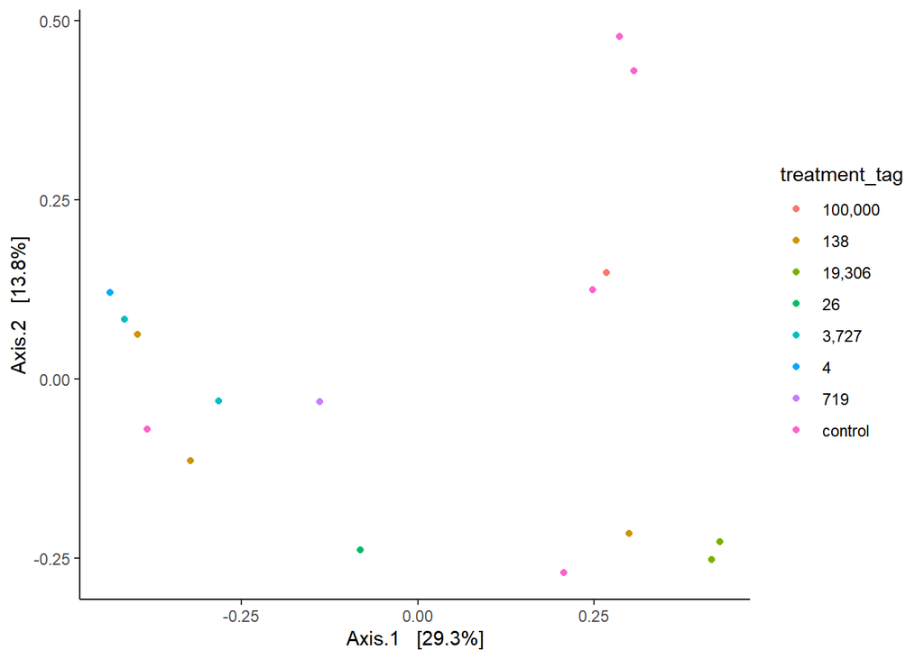

### 3.2 NMDS Bray Curtis

I looked at 2D (k=2) and 3D (k=3) NMDS

Interpretation of stress values:

- < 0.05 = excellent,
- 0.05–0.1 = very good,
- 0.1–0.2 = usable but some distortion,
- > 0.2 = not reliable

Weak ties mean that few identical distances were tied during ranking, which is good, it indicates the data have good variability.

```
## Square root transformation
## Wisconsin double standardization
## *** Best solution repeated 9 times
```

```
## NMDS with k=3 results:
```

```
## Stress value: 0.06750956
```

```
## Square root transformation
## Wisconsin double standardization
## *** Best solution repeated 3 times
```

```
## NMDS with k=2 results:
```

```
## Stress value: 0.1062023
```

Based on stress values, I continued with:

```
## Selected model: ord_NMDS_k2 ; Stress value: 0.1062023
```

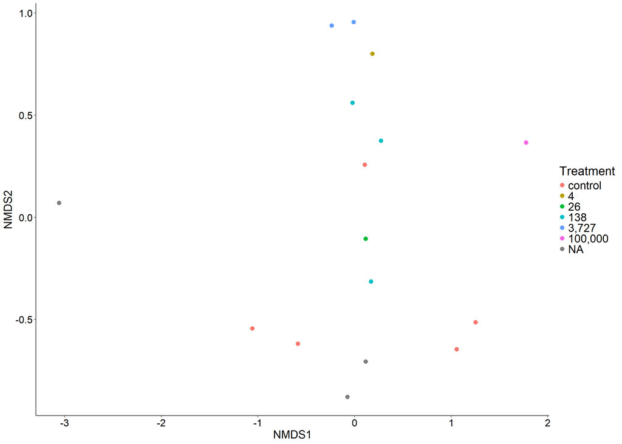

#### 3.2.1 Statistics

##### 3.2.1.1 PERMANOVA

```
## PERMANOVA Results for Bray-Curtis Distance:
```

```
## Testing effects of treatment on microbial community composition.
```

```
##          Df SumOfSqs        R2        F Pr(>F)
## Model     7 3.197358 0.5588573 1.447817  0.043
## Residual  8 2.523884 0.4411427       NA     NA
## Total    15 5.721242 1.0000000       NA     NA
```

```
##
## Interpretation:
```

```
## - Significant p-values (< 0.05) indicate a statistically significant effect of that factor on community composition.
```

```
## - R² values represent the proportion of variation explained by each factor.
```

##### 3.2.1.2 Beta dispersion

betadisper measures the spread (i.e., variability) of samples around the group centroid in NMDS (or distance) space. It’s analogous to a Levene’s test for homogeneity of variance, but for multivariate data. It helps to understand if your PERMANOVA results are driven more by location (centroid differences) or spread (dispersion differences).

- **If p > 0.05**: No evidence of unequal dispersion → You can trust group separation in PERMANOVA.
- **If p < 0.05**: Significant dispersion → Group differences in PERMANOVA **may be confounded** by group variance, **not just location**.

```
## Analysis of Variance Table
##
## Response: Distances
##           Df  Sum Sq  Mean Sq F value   Pr(>F)
## Groups     7 0.83514 0.119305  8.0734 0.004276 **
## Residuals  8 0.11822 0.014778
## ---
## Signif. codes:  0 '***' 0.001 '**' 0.01 '*' 0.05 '.' 0.1 ' ' 1
```

```
## Summary of distances to group centroids:
```

```
##       treatment DistanceToCentroid
## Ven11   control          0.5890158
## Ven13    19,306          0.1626719
## Ven14       138          0.4170954
## Ven15   100,000          0.0000000
## Ven17   control          0.5513011
## Ven19         4          0.0000000
```

Create boxplot

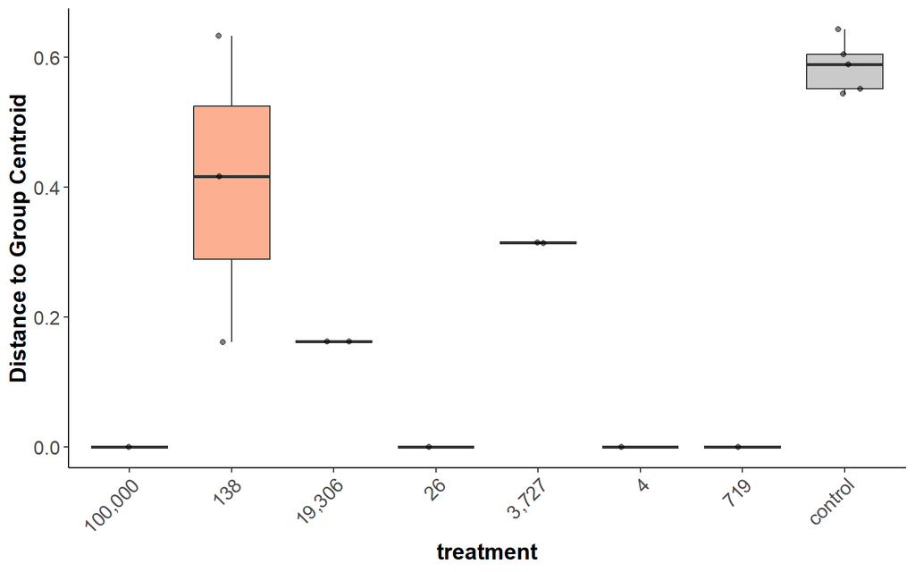